# Tarea 0

Isabel Sutil Martin

15/9/2021

# Ejercicios

### Ejercicio 1

##### Usando la función sample crea un vector dado_honesto con 100 números del 1 al 6. Haz una tabla de frecuencias absolutas (de dos maneras, con table y dplyr) y una tabla de frecuencias relativas.

Se importan las librerias **tidyverse** y **dplyr**. Posteriormente se crea la muestra con los 100 numeros

```r
library(tidyverse)
library(dplyr)
(dado_honesto = sample(1:6, 100, replace = TRUE))
```

```
##   [1] 6 4 6 5 4 3 2 5 4 6 1 6 2 6 6 5 5 4 5 5 3 6 5 3 5 2 5 5 4 6 3 1 4 3 1 2 2
##  [38] 3 3 4 5 6 6 5 2 2 1 2 4 6 3 6 2 6 1 3 4 5 6 6 5 3 3 3 1 4 3 6 5 3 6 4 5 5
##  [75] 3 4 2 6 1 4 5 6 1 5 5 6 5 2 5 2 2 1 5 2 3 5 5 3 3 2
```

Frecuencias con table

```r
table(dado_honesto) #frecuencia absoluta
```

```
## dado_honesto
##  1  2  3  4  5  6
##  9 15 18 13 25 20
```

```r
signif(prop.table(table(dado_honesto)),2) # frecuencia relativa
```

```
## dado_honesto
##    1    2    3    4    5    6
## 0.09 0.15 0.18 0.13 0.25 0.20
```

Frecuencias con dplyr

```r
tabla = as.data.frame(dado_honesto)

#frecuencia absoluta
tabla %>%
  count(dado_honesto)
```

```
##   dado_honesto  n
## 1            1  9
## 2            2 15
## 3            3 18
## 4            4 13
## 5            5 25
## 6            6 20
```

```r
# frecuencia relativa
 tabla %>%
        count(dado_honesto) %>%
          mutate(dado_honesto, relFreq = prop.table(n), n=NULL)
```

```
##   dado_honesto relFreq
## 1            1    0.09
## 2            2    0.15
## 3            3    0.18
## 4            4    0.13
## 5            5    0.25
## 6            6    0.20
```

### Ejercicio 2

##### A continuación crea un nuevo vector dado_cargado de manera que la probabilidad de que el número elegido valga 6 sea el doble que la probabilidad de elegir cualquiera de los cinco números restantes. De nuevo, haz tablas de frecuencias absolutas y relativas de este segundo vector.

Creamos dado_cargado y hacemos las tablas de frecuencias usando table y dplyr

```r
dado_cargado = sample(1:6, 100, replace = TRUE, prob = c(1/7, 1/7, 1/7, 1/7, 1/7, 2/7))

#table

table(dado_cargado) #frecuencia absoluta
```

```
## dado_cargado
##  1  2  3  4  5  6
## 10 14 23 16  9 28
```

```r
signif(prop.table(table(dado_cargado)),2) # frecuencia relativa
```

```
## dado_cargado
##    1    2    3    4    5    6
## 0.10 0.14 0.23 0.16 0.09 0.28
```

```r
#dplyr

tabla = as.data.frame(dado_cargado)

#frecuencia absoluta
tabla %>%
  count(dado_cargado)
```

```
##   dado_cargado  n
## 1            1 10
## 2            2 14
## 3            3 23
## 4            4 16
## 5            5  9
## 6            6 28
```

```r
# frecuencia relativa
 tabla %>%
        count(dado_cargado) %>%
          mutate(dado_cargado, relFreq = prop.table(n), n=NULL)
```

```
##   dado_cargado relFreq
## 1            1    0.10
## 2            2    0.14
## 3            3    0.23
## 4            4    0.16
## 5            5    0.09
## 6            6    0.28
```

### Ejercicio 3

##### 1, 2, 2, 3, 3, 3, 4, 4, 4, 4, 5, 5, 5, 5, 5

##### 1, 2, 3, 4, 1, 2, 3, 4, 1, 2, 3, 4, 1, 2, 3, 4

```r
(v1 = rep(seq(4:1), each = 4))
```

```
##  [1] 1 1 1 1 2 2 2 2 3 3 3 3 4 4 4 4
```

```r
(v2 = rep(seq(1:5), times = c(1,2,3,4,5)))
```

```
##  [1] 1 2 2 3 3 3 4 4 4 4 5 5 5 5 5
```

```r
(v3 = rep(seq(1:4), times = 4))
```

```
##  [1] 1 2 3 4 1 2 3 4 1 2 3 4 1 2 3 4
```

### Ejercicio 4

##### Utilizando la tabla mpg de la librería tidyverse crea una tabla mpg2 que:

##### Contenga las filas en las que la variable class toma el valor pickup

##### Contenga las columnas de la tabla original cuyos nombres empiezan por c.

```r
(mpg2 = mpg %>%
  filter(mpg$class == 'pickup')%>%  #Primera condicion
    select(starts_with('c')))        #Segunda condicion
```

```
## # A tibble: 33 x 3
##      cyl   cty class
##    <int> <int> <chr>
##  1     6    15 pickup
##  2     6    14 pickup
##  3     6    13 pickup
##  4     6    14 pickup
##  5     8    14 pickup
##  6     8    14 pickup
##  7     8     9 pickup
##  8     8    11 pickup
##  9     8    11 pickup
## 10     8    12 pickup
## # ... with 23 more rows
```

### Ejercicio 5

##### Descarga el fichero census.dta (http://www.stata-press.com/data/r8/census.dta). Averigua de qué tipo de fichero se trata y usa la herramienta Import DataSet del panel Environment de RStudio para leer con R los datos de ese fichero. Después completa los siguientes apartados con esos datos y usando dplyr y ggplot:

Importamos las librerias que vamos a utilizar y leemos el fichero

```r
library(haven)
census = read_dta("http://www.stata-press.com/data/r8/census.dta")
```

- 5.1 ¿Cuáles son las poblaciones totales de las regiones censales?

Creamos una nueva tabla “tabla_poblacion” con la informacion

```r
(tabla_poblacion <- census %>%
  group_by(region) %>%
  summarise(poblacion = sum(pop)))
```

```
## # A tibble: 4 x 2
##        region poblacion
##     <dbl+lbl>     <dbl>
## 1 1 [NE]       49135283
## 2 2 [N Cntrl]  58865670
## 3 3 [South]    74734029
## 4 4 [West]     43172490
```

- 5.2 Representa esas poblaciones totales en un diagrama de barras (una barra por región censal).

Para poder realizar un diagrama de la nueva tabla hemos de importar **ggplot2**

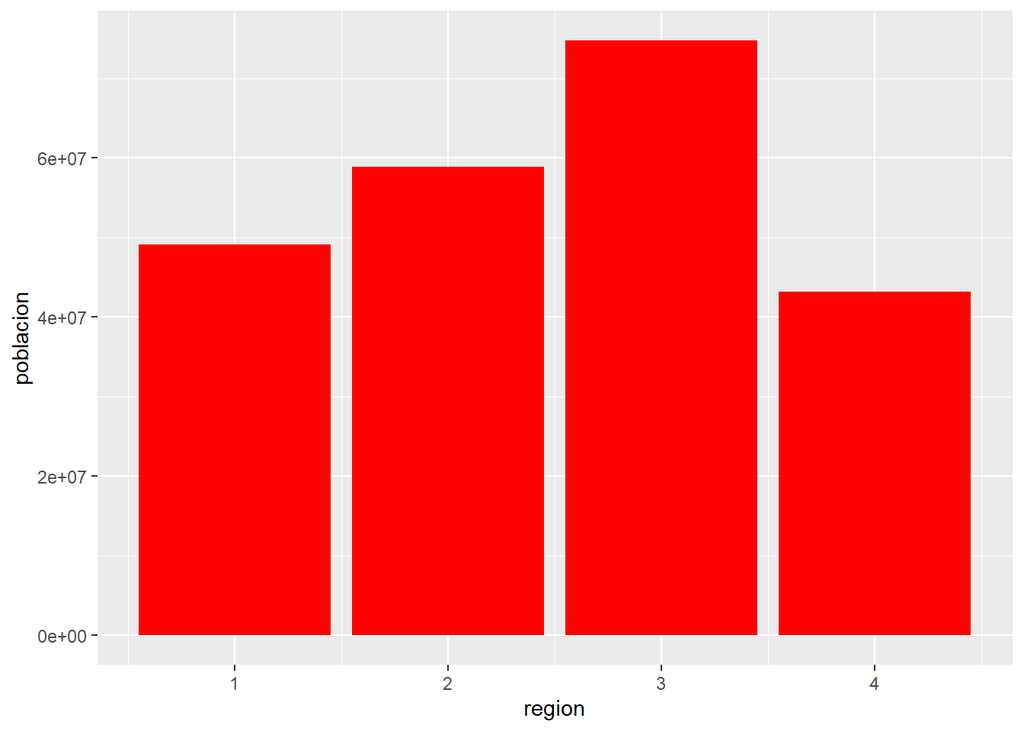

```r
library(ggplot2)

ggplot(tabla_poblacion) + geom_col(aes(region, poblacion), fill = 'red')
```

- 5.3 Ordena los estados por población, de mayor a menor.

Se selecciona el estado y se ordena en funcion de la poblacion

```r
(census %>%
   select(state,pop) %>%
   arrange(across(pop,desc)))
```

```
## # A tibble: 50 x 2
##    state             pop
##    <chr>           <dbl>
##  1 California   23667902
##  2 New York     17558072
##  3 Texas        14229191
##  4 Pennsylvania 11863895
##  5 Illinois     11426518
##  6 Ohio         10797630
##  7 Florida       9746324
##  8 Michigan      9262078
##  9 New Jersey    7364823
## 10 N. Carolina   5881766
## # ... with 40 more rows
```

- 5.4 Crea una nueva variable que contenga la tasa de divorcios /matrimonios para cada estado.

Se crea la nueva columna en una nueva tabla “tabla_tasa” que contiene todos los campos. Solo se visualiza el estado, divorcios, matrimonios y la tasa

```r
tabla_tasa = census %>%
  mutate(tasa = divorce/marriage)

(tabla_tasa%>%
  select(state,divorce, marriage, tasa))
```

```
## # A tibble: 50 x 4
##    state       divorce marriage  tasa
##    <chr>         <dbl>    <dbl> <dbl>
##  1 Alabama       26745    49018 0.546
##  2 Alaska         3517     5361 0.656
##  3 Arizona       19908    30223 0.659
##  4 Arkansas      15882    26513 0.599
##  5 California   133541   210864 0.633
##  6 Colorado      18571    34917 0.532
##  7 Connecticut   13488    26048 0.518
##  8 Delaware       2313     4437 0.521
##  9 Florida       71579   108344 0.661
## 10 Georgia       34743    70638 0.492
## # ... with 40 more rows
```

- 5.5 Si nos preguntamos cuáles son los estados más envejecidos podemos responder de dos maneras. Mirando la edad mediana o mirando en qué estados la franja de mayor edad representa una proporción más alta de la población total. Haz una tabla en la que aparezcan los valores de estos dos criterios, ordenada según la edad mediana decreciente y muestra los 10 primeros estados de esa tabla.

Hacemos la nueva tabla “tabla_envejecidos”

```r
tabla_envejecidos = census %>%
  arrange(desc(medage)) %>%     #edad mediana decreciente
  mutate(prop65= pop65p/pop) %>% #proporcion de franja de mayor edad
  select(state,medage,prop65) %>%
  head(10)

(tabla_envejecidos)
```

```
## # A tibble: 10 x 3
##    state         medage prop65
##    <chr>          <dbl>  <dbl>
##  1 Florida         34.7  0.173
##  2 New Jersey      32.2  0.117
##  3 Pennsylvania    32.1  0.129
##  4 Connecticut     32    0.117
##  5 New York        31.9  0.123
##  6 Rhode Island    31.8  0.134
##  7 Massachusetts   31.2  0.127
##  8 Missouri        30.9  0.132
##  9 Arkansas        30.6  0.137
## 10 Maine           30.4  0.125
```

- 5.6 Haz un histograma (con 10 intervalos) de los valores de la variable medage (edad mediana) y con la curva de densidad de la variable superpuesta.

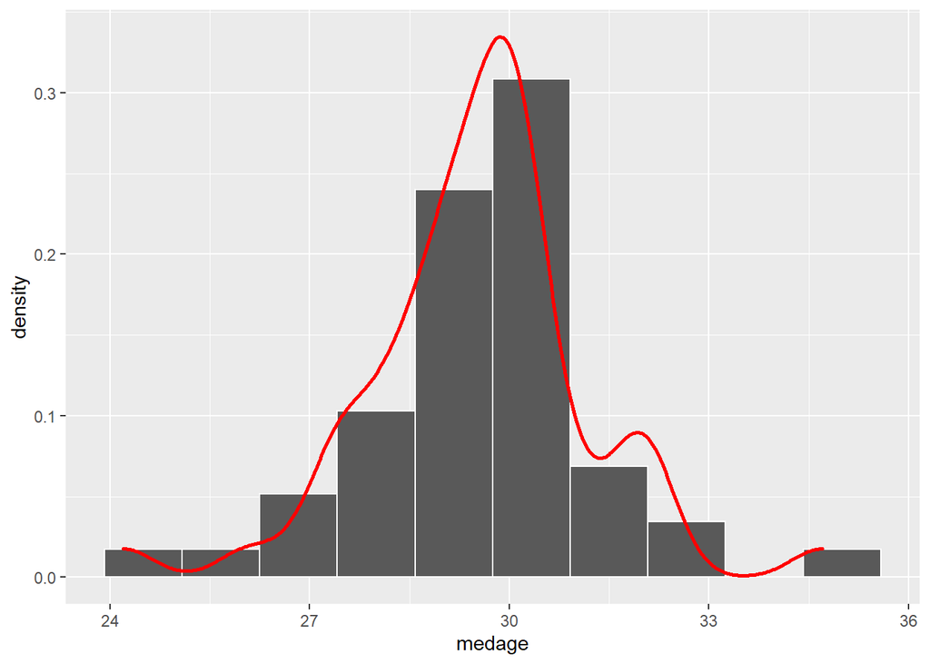

```r
ggplot(census, aes(x = medage)) +
  geom_histogram(aes(y=stat(density)), bins=10, color="white")  +
  geom_density(color="red", size=1)
```